# Анализ продажи игр

## Описание проекта

Вы работаете в интернет-магазине «Стримчик», который продаёт по всему миру компьютерные игры. Из открытых источников доступны исторические данные о продажах игр, оценки пользователей и экспертов, жанры и платформы (например, Xbox или PlayStation). Вам нужно выявить определяющие успешность игры закономерности. Это позволит сделать ставку на потенциально популярный продукт и спланировать рекламные кампании.

Перед вами данные до 2016 года. Представим, что сейчас декабрь 2016 г., и вы планируете кампанию на 2017-й. Нужно отработать принцип работы с данными. Неважно, прогнозируете ли вы продажи на 2017 год по данным 2016-го или же 2027-й — по данным 2026 года.

В наборе данных попадается аббревиатура ESRB (Entertainment Software Rating Board) — это ассоциация, определяющая возрастной рейтинг компьютерных игр. ESRB оценивает игровой контент и присваивает ему подходящую возрастную категорию, например, «Для взрослых», «Для детей младшего возраста» или «Для подростков».

Данные представлены в файле */datasets/games.csv*

**Таблица `games`:**

- *Name* — название игры
- *Platform* — платформа
- *Year_of_Release* — год выпуска
- *Genre* — жанр игры
- *NA_sales* — продажи в Северной Америке (миллионы проданных копий)
- *EU_sales* — продажи в Европе (миллионы проданных копий)
- *JP_sales* — продажи в Японии (миллионы проданных копий)
- *Other_sales* — продажи в других странах (миллионы проданных копий)
- *Critic_Score* — оценка критиков (максимум 100)
- *User_Score* — оценка пользователей (максимум 10)
- *Rating* — рейтинг от организации ESRB (англ. Entertainment Software Rating Board). Эта ассоциация - определяет рейтинг компьютерных игр и присваивает им подходящую возрастную категорию.

Данные за 2016 год могут быть неполными.

### Оглавление

- 1. Открытие данных
  - Вывод
- 2. Предобработка данных
  - Вывод
- 3. Анализ данных
  - Вывод
- 4. Изученение пользователей из разных регионов
  - Вывод
- 5. Проверка гипотез
  - Вывод
- 6. Общий вывод и рекомендации

## 1. Открытие и изучение данных

```python
# For better figure's quality
%config InlineBackend.figure_format = 'retina'
import pandas as pd
import numpy as np
import matplotlib.pyplot as plt
from scipy import stats as st
```

```python
# workaround to use praktikum file system as well as local windows system",
try:
    games = pd.read_csv("/datasets/games.csv")
except:
    games = pd.read_csv("datasets/games.csv")
```

```python
games.head(10)
```

|  | Name | Platform | Year_of_Release | Genre | NA_sales | EU_sales | JP_sales | Other_sales | Critic_Score | User_Score | Rating |
| --- | --- | --- | --- | --- | --- | --- | --- | --- | --- | --- | --- |
| 0 | Wii Sports | Wii | 2006.0 | Sports | 41.36 | 28.96 | 3.77 | 8.45 | 76.0 | 8 | E |
| 1 | Super Mario Bros. | NES | 1985.0 | Platform | 29.08 | 3.58 | 6.81 | 0.77 | NaN | NaN | NaN |
| 2 | Mario Kart Wii | Wii | 2008.0 | Racing | 15.68 | 12.76 | 3.79 | 3.29 | 82.0 | 8.3 | E |
| 3 | Wii Sports Resort | Wii | 2009.0 | Sports | 15.61 | 10.93 | 3.28 | 2.95 | 80.0 | 8 | E |
| 4 | Pokemon Red/Pokemon Blue | GB | 1996.0 | Role-Playing | 11.27 | 8.89 | 10.22 | 1.00 | NaN | NaN | NaN |
| 5 | Tetris | GB | 1989.0 | Puzzle | 23.20 | 2.26 | 4.22 | 0.58 | NaN | NaN | NaN |
| 6 | New Super Mario Bros. | DS | 2006.0 | Platform | 11.28 | 9.14 | 6.50 | 2.88 | 89.0 | 8.5 | E |
| 7 | Wii Play | Wii | 2006.0 | Misc | 13.96 | 9.18 | 2.93 | 2.84 | 58.0 | 6.6 | E |
| 8 | New Super Mario Bros. Wii | Wii | 2009.0 | Platform | 14.44 | 6.94 | 4.70 | 2.24 | 87.0 | 8.4 | E |
| 9 | Duck Hunt | NES | 1984.0 | Shooter | 26.93 | 0.63 | 0.28 | 0.47 | NaN | NaN | NaN |

Данные прочитаны, разделитель указан верный.

Проверим общие показатели датафрейма.

```python
games.info()
```

```
<class 'pandas.core.frame.DataFrame'>
RangeIndex: 16715 entries, 0 to 16714
Data columns (total 11 columns):
 #   Column           Non-Null Count  Dtype
---  ------           --------------  -----
 0   Name             16713 non-null  object
 1   Platform         16715 non-null  object
 2   Year_of_Release  16446 non-null  float64
 3   Genre            16713 non-null  object
 4   NA_sales         16715 non-null  float64
 5   EU_sales         16715 non-null  float64
 6   JP_sales         16715 non-null  float64
 7   Other_sales      16715 non-null  float64
 8   Critic_Score     8137 non-null   float64
 9   User_Score       10014 non-null  object
 10  Rating           9949 non-null   object
dtypes: float64(6), object(5)
memory usage: 1.4+ MB
```

Все названия колонок нужно привести к нижнему регистру. Пользовательский рейтинг хранится в формате строки, а не float, также год выпуска можно хранить не в числовом виде, а в виде строки или формата даты-времени. Есть пропущенные строки, посмотрим подробнее.

```python
games.isna().sum()
```

```
Name                  2
Platform              0
Year_of_Release     269
Genre                 2
NA_sales              0
EU_sales              0
JP_sales              0
Other_sales           0
Critic_Score       8578
User_Score         6701
Rating             6766
dtype: int64
```

Пропуски содержаться в датах релиза и рейтингах. Есть пропущенные значение в названии игр, посмотрим внимательные.

```python
games[games['Name'].isna()]
```

|  | Name | Platform | Year_of_Release | Genre | NA_sales | EU_sales | JP_sales | Other_sales | Critic_Score | User_Score | Rating |
| --- | --- | --- | --- | --- | --- | --- | --- | --- | --- | --- | --- |
| 659 | NaN | GEN | 1993.0 | NaN | 1.78 | 0.53 | 0.00 | 0.08 | NaN | NaN | NaN |
| 14244 | NaN | GEN | 1993.0 | NaN | 0.00 | 0.00 | 0.03 | 0.00 | NaN | NaN | NaN |

В ходе предобработки данных предстоит решить, что делать с этими пропусками. Так как таких записей всего лишь 2, можно заменить здесь пропуски на название `unknown`.

Проверим, есть ли полные дубликаты в датафрейме.

```python
games.duplicated().sum()
```

```
0
```

Дубликатов нет.

### Вывод раздела 1

Мы прочитали исходные данные, определили возможные проблемы с типами данных, пропусками в параметрах и названии колонок.

## 2. Предобработка данных

Приведем все названия колонок к нижнему регистру.

```python
games.columns = [x.lower() for x in games.columns]
```

```python
games.info()
```

```
<class 'pandas.core.frame.DataFrame'>
RangeIndex: 16715 entries, 0 to 16714
Data columns (total 11 columns):
 #   Column           Non-Null Count  Dtype
---  ------           --------------  -----
 0   name             16713 non-null  object
 1   platform         16715 non-null  object
 2   year_of_release  16446 non-null  float64
 3   genre            16713 non-null  object
 4   na_sales         16715 non-null  float64
 5   eu_sales         16715 non-null  float64
 6   jp_sales         16715 non-null  float64
 7   other_sales      16715 non-null  float64
 8   critic_score     8137 non-null   float64
 9   user_score       10014 non-null  object
 10  rating           9949 non-null   object
dtypes: float64(6), object(5)
memory usage: 1.4+ MB
```

Как мы уже увидели в предыдущем разделе рейтинг среди игроков хранится в виде строки, посмотрим какие значения встречаются.

```python
games['user_score'].value_counts()
```

```
tbd    2424
7.8     324
8       290
8.2     282
8.3     254
       ...
1.3       2
9.6       2
0.7       2
0         1
9.7       1
Name: user_score, Length: 96, dtype: int64
```

```python
games[games['user_score'] == 'tbd'].head(5)
```

|  | name | platform | year_of_release | genre | na_sales | eu_sales | jp_sales | other_sales | critic_score | user_score | rating |
| --- | --- | --- | --- | --- | --- | --- | --- | --- | --- | --- | --- |
| 119 | Zumba Fitness | Wii | 2010.0 | Sports | 3.45 | 2.59 | 0.0 | 0.66 | NaN | tbd | E |
| 301 | Namco Museum: 50th Anniversary | PS2 | 2005.0 | Misc | 2.08 | 1.35 | 0.0 | 0.54 | 61.0 | tbd | E10+ |
| 520 | Zumba Fitness 2 | Wii | 2011.0 | Sports | 1.51 | 1.03 | 0.0 | 0.27 | NaN | tbd | T |
| 645 | uDraw Studio | Wii | 2010.0 | Misc | 1.65 | 0.57 | 0.0 | 0.20 | 71.0 | tbd | E |
| 657 | Frogger's Adventures: Temple of the Frog | GBA | NaN | Adventure | 2.15 | 0.18 | 0.0 | 0.07 | 73.0 | tbd | E |

Практически 20% от всех присутствующих значений рейтинга среди пользователей занимают значения *tbd*. Это значение показывает, что рейтинг еще не определен и ожидается для игр в том источнике, который использовался для получения данных для анализа. Такое значение встречается для, в том числе, старых игр (от 2005 года, например). Скорее всего, рейтинг среди пользователей в таких случаях не определен и не будет определен в дальнейшем, либо сбор данных от пользователей для этой игры прекращен. Такие значения можно заменить на **пропуски**, так как в действительно для анализа нужны именно данные в наличии, кроме того, в этом столбце нужны значения в численном формате для возможности анализа. Альтернативным подходом можно считать выделения таких значений в отдельный столбец.

```python
# Updated
games['user_score'] = games['user_score'].replace('tbd', np.nan)
```

```python
games.info()
```

```
<class 'pandas.core.frame.DataFrame'>
RangeIndex: 16715 entries, 0 to 16714
Data columns (total 11 columns):
 #   Column           Non-Null Count  Dtype
---  ------           --------------  -----
 0   name             16713 non-null  object
 1   platform         16715 non-null  object
 2   year_of_release  16446 non-null  float64
 3   genre            16713 non-null  object
 4   na_sales         16715 non-null  float64
 5   eu_sales         16715 non-null  float64
 6   jp_sales         16715 non-null  float64
 7   other_sales      16715 non-null  float64
 8   critic_score     8137 non-null   float64
 9   user_score       7590 non-null   object
 10  rating           9949 non-null   object
dtypes: float64(6), object(5)
memory usage: 1.4+ MB
```

```python
games['user_score'].value_counts()
```

```
7.8    324
8      290
8.2    282
8.3    254
8.5    253
      ...
1.3      2
9.6      2
0.7      2
0        1
9.7      1
Name: user_score, Length: 95, dtype: int64
```

Теперь оставшиеся значения можно преобразовать в числовой формат.

```python
games['user_score'] = games['user_score'].astype(float)
```

```python
games.info()
```

```
<class 'pandas.core.frame.DataFrame'>
RangeIndex: 16715 entries, 0 to 16714
Data columns (total 11 columns):
 #   Column           Non-Null Count  Dtype
---  ------           --------------  -----
 0   name             16713 non-null  object
 1   platform         16715 non-null  object
 2   year_of_release  16446 non-null  float64
 3   genre            16713 non-null  object
 4   na_sales         16715 non-null  float64
 5   eu_sales         16715 non-null  float64
 6   jp_sales         16715 non-null  float64
 7   other_sales      16715 non-null  float64
 8   critic_score     8137 non-null   float64
 9   user_score       7590 non-null   float64
 10  rating           9949 non-null   object
dtypes: float64(7), object(4)
memory usage: 1.4+ MB
```

```python
games.sample(5)
```

|  | name | platform | year_of_release | genre | na_sales | eu_sales | jp_sales | other_sales | critic_score | user_score | rating |
| --- | --- | --- | --- | --- | --- | --- | --- | --- | --- | --- | --- |
| 5956 | Kurohyou: Ryu ga Gotoku Shinshou | PSP | 2010.0 | Adventure | 0.00 | 0.00 | 0.29 | 0.00 | NaN | NaN | NaN |
| 14142 | FabStyle | 3DS | 2011.0 | Strategy | 0.00 | 0.00 | 0.03 | 0.00 | NaN | NaN | NaN |
| 15986 | Hiiro no Kakera Portable | PSP | 2008.0 | Adventure | 0.00 | 0.00 | 0.02 | 0.00 | NaN | NaN | NaN |
| 14185 | Need for Speed (2015) | PC | 2016.0 | Racing | 0.00 | 0.03 | 0.00 | 0.00 | NaN | NaN | NaN |
| 6731 | SBK Superbike World Championship | PS3 | 2008.0 | Racing | 0.12 | 0.11 | 0.00 | 0.02 | 59.0 | 6.1 | E10+ |

#### Разбор пропусков.

```python
games.isna().sum()
```

```
name                  2
platform              0
year_of_release     269
genre                 2
na_sales              0
eu_sales              0
jp_sales              0
other_sales           0
critic_score       8578
user_score         9125
rating             6766
dtype: int64
```

В изначальных данных много пропущенных значений в различных рейтингах, которые, скорее всего, вызваны тем, что открытые источники, которые использовались для получения данных для анализа, не имеют информации о части игр, либо они выходили на рынках, данных по которым нет у этих источников.

**Оставим пропуски в рейтингах `critic_score`, `user_score` и `rating` как есть**, так как их нельзя заменить каким-либо подходящим значением без искажения данных для анализа. Также этих строчек достаточно много и в других колонках есть полезная информация, а значит удалять их из рассмотрения нельзя.

Вызывают интерес 2 записи с пропусками значений в названии игры и жанре, посмотрим на них.

```python
games[games['name'].isna()]
```

|  | name | platform | year_of_release | genre | na_sales | eu_sales | jp_sales | other_sales | critic_score | user_score | rating |
| --- | --- | --- | --- | --- | --- | --- | --- | --- | --- | --- | --- |
| 659 | NaN | GEN | 1993.0 | NaN | 1.78 | 0.53 | 0.00 | 0.08 | NaN | NaN | NaN |
| 14244 | NaN | GEN | 1993.0 | NaN | 0.00 | 0.00 | 0.03 | 0.00 | NaN | NaN | NaN |

Так как таких записей всего 2 от всей выборки и дата выпуска игры очень давняя, **эти записи можно просто удалить**. Это не исказит анализ.

```python
games.dropna(subset=['name'], inplace=True)
```

```python
games.info()
```

```
<class 'pandas.core.frame.DataFrame'>
Int64Index: 16713 entries, 0 to 16714
Data columns (total 11 columns):
 #   Column           Non-Null Count  Dtype
---  ------           --------------  -----
 0   name             16713 non-null  object
 1   platform         16713 non-null  object
 2   year_of_release  16444 non-null  float64
 3   genre            16713 non-null  object
 4   na_sales         16713 non-null  float64
 5   eu_sales         16713 non-null  float64
 6   jp_sales         16713 non-null  float64
 7   other_sales      16713 non-null  float64
 8   critic_score     8137 non-null   float64
 9   user_score       7590 non-null   float64
 10  rating           9949 non-null   object
dtypes: float64(7), object(4)
memory usage: 1.5+ MB
```

Остались пропуски в столбце с датой выхода игры.

```python
games[games['year_of_release'].isna()]
```

|  | name | platform | year_of_release | genre | na_sales | eu_sales | jp_sales | other_sales | critic_score | user_score | rating |
| --- | --- | --- | --- | --- | --- | --- | --- | --- | --- | --- | --- |
| 183 | Madden NFL 2004 | PS2 | NaN | Sports | 4.26 | 0.26 | 0.01 | 0.71 | 94.0 | 8.5 | E |
| 377 | FIFA Soccer 2004 | PS2 | NaN | Sports | 0.59 | 2.36 | 0.04 | 0.51 | 84.0 | 6.4 | E |
| 456 | LEGO Batman: The Videogame | Wii | NaN | Action | 1.80 | 0.97 | 0.00 | 0.29 | 74.0 | 7.9 | E10+ |
| 475 | wwe Smackdown vs. Raw 2006 | PS2 | NaN | Fighting | 1.57 | 1.02 | 0.00 | 0.41 | NaN | NaN | NaN |
| 609 | Space Invaders | 2600 | NaN | Shooter | 2.36 | 0.14 | 0.00 | 0.03 | NaN | NaN | NaN |
| ... | ... | ... | ... | ... | ... | ... | ... | ... | ... | ... | ... |
| 16373 | PDC World Championship Darts 2008 | PSP | NaN | Sports | 0.01 | 0.00 | 0.00 | 0.00 | 43.0 | NaN | E10+ |
| 16405 | Freaky Flyers | GC | NaN | Racing | 0.01 | 0.00 | 0.00 | 0.00 | 69.0 | 6.5 | T |
| 16448 | Inversion | PC | NaN | Shooter | 0.01 | 0.00 | 0.00 | 0.00 | 59.0 | 6.7 | M |
| 16458 | Hakuouki: Shinsengumi Kitan | PS3 | NaN | Adventure | 0.01 | 0.00 | 0.00 | 0.00 | NaN | NaN | NaN |
| 16522 | Virtua Quest | GC | NaN | Role-Playing | 0.01 | 0.00 | 0.00 | 0.00 | 55.0 | 5.5 | T |

269 rows × 11 columns

```python
games[games['name'] == 'LEGO Batman: The Videogame']
```

|  | name | platform | year_of_release | genre | na_sales | eu_sales | jp_sales | other_sales | critic_score | user_score | rating |
| --- | --- | --- | --- | --- | --- | --- | --- | --- | --- | --- | --- |
| 397 | LEGO Batman: The Videogame | X360 | 2008.0 | Action | 2.04 | 1.02 | 0.0 | 0.32 | 76.0 | 7.9 | E10+ |
| 456 | LEGO Batman: The Videogame | Wii | NaN | Action | 1.80 | 0.97 | 0.0 | 0.29 | 74.0 | 7.9 | E10+ |
| 460 | LEGO Batman: The Videogame | DS | 2008.0 | Action | 1.75 | 1.01 | 0.0 | 0.29 | 72.0 | 8.0 | E10+ |
| 1519 | LEGO Batman: The Videogame | PS3 | 2008.0 | Action | 0.72 | 0.39 | 0.0 | 0.19 | 75.0 | 7.7 | E10+ |
| 1538 | LEGO Batman: The Videogame | PSP | NaN | Action | 0.57 | 0.44 | 0.0 | 0.27 | 73.0 | 7.4 | E10+ |
| 1553 | LEGO Batman: The Videogame | PS2 | 2008.0 | Action | 0.72 | 0.03 | 0.0 | 0.52 | 77.0 | 8.9 | E10+ |
| 12465 | LEGO Batman: The Videogame | PC | 2008.0 | Action | 0.02 | 0.03 | 0.0 | 0.01 | 80.0 | 7.8 | E10+ |

```python
games[games['name'] == 'FIFA Soccer 2004']
```

|  | name | platform | year_of_release | genre | na_sales | eu_sales | jp_sales | other_sales | critic_score | user_score | rating |
| --- | --- | --- | --- | --- | --- | --- | --- | --- | --- | --- | --- |
| 377 | FIFA Soccer 2004 | PS2 | NaN | Sports | 0.59 | 2.36 | 0.04 | 0.51 | 84.0 | 6.4 | E |
| 2606 | FIFA Soccer 2004 | XB | 2003.0 | Sports | 0.24 | 0.49 | 0.00 | 0.05 | 82.0 | 8.2 | E |
| 12029 | FIFA Soccer 2004 | GC | 2003.0 | Sports | 0.05 | 0.01 | 0.00 | 0.00 | 83.0 | 6.2 | E |
| 13086 | FIFA Soccer 2004 | GBA | 2003.0 | Sports | 0.04 | 0.01 | 0.00 | 0.00 | 82.0 | 7.9 | E |

Часто игры выходят сразу на нескольких платформах, поэтому разумно будет предположить, что пропущенные значения для конкретной платформы по дате выпуска можно заменить на дату выхода на другой платформе.

Создадим вспомогательный датафрейм с временами выхода игр.

```python
games_dates = games.groupby('name')['year_of_release'].max()
```

А также вспомогательную функцию.

```python
def fill_dates(row):
    if pd.isnull(row['year_of_release']):
        name = row['name']
        return games_dates[name]
    else:
        return row['year_of_release']
```

```python
games['year_of_release'] = games.apply(fill_dates, axis=1)
```

```python
games['year_of_release'].isna().sum()
```

```
146
```

```python
games[games['name'] == 'FIFA Soccer 2004']
```

|  | name | platform | year_of_release | genre | na_sales | eu_sales | jp_sales | other_sales | critic_score | user_score | rating |
| --- | --- | --- | --- | --- | --- | --- | --- | --- | --- | --- | --- |
| 377 | FIFA Soccer 2004 | PS2 | 2003.0 | Sports | 0.59 | 2.36 | 0.04 | 0.51 | 84.0 | 6.4 | E |
| 2606 | FIFA Soccer 2004 | XB | 2003.0 | Sports | 0.24 | 0.49 | 0.00 | 0.05 | 82.0 | 8.2 | E |
| 12029 | FIFA Soccer 2004 | GC | 2003.0 | Sports | 0.05 | 0.01 | 0.00 | 0.00 | 83.0 | 6.2 | E |
| 13086 | FIFA Soccer 2004 | GBA | 2003.0 | Sports | 0.04 | 0.01 | 0.00 | 0.00 | 82.0 | 7.9 | E |

Количество пропусков уменьшилось, но остались те игры, для которых даты выхода нет совсем.

```python
games[games['year_of_release'].isna()]
```

|  | name | platform | year_of_release | genre | na_sales | eu_sales | jp_sales | other_sales | critic_score | user_score | rating |
| --- | --- | --- | --- | --- | --- | --- | --- | --- | --- | --- | --- |
| 475 | wwe Smackdown vs. Raw 2006 | PS2 | NaN | Fighting | 1.57 | 1.02 | 0.00 | 0.41 | NaN | NaN | NaN |
| 627 | Rock Band | X360 | NaN | Misc | 1.93 | 0.33 | 0.00 | 0.21 | 92.0 | 8.2 | T |
| 657 | Frogger's Adventures: Temple of the Frog | GBA | NaN | Adventure | 2.15 | 0.18 | 0.00 | 0.07 | 73.0 | NaN | E |
| 805 | Rock Band | Wii | NaN | Misc | 1.33 | 0.56 | 0.00 | 0.20 | 80.0 | 6.3 | T |
| 1142 | Rock Band | PS3 | NaN | Misc | 0.99 | 0.41 | 0.00 | 0.22 | 92.0 | 8.4 | T |
| ... | ... | ... | ... | ... | ... | ... | ... | ... | ... | ... | ... |
| 16277 | Homeworld Remastered Collection | PC | NaN | Strategy | 0.00 | 0.01 | 0.00 | 0.00 | 86.0 | 8.2 | E10+ |
| 16288 | Shorts | DS | NaN | Platform | 0.01 | 0.00 | 0.00 | 0.00 | NaN | NaN | E10+ |
| 16348 | Agarest Senki: Re-appearance | PS3 | NaN | Role-Playing | 0.00 | 0.00 | 0.01 | 0.00 | NaN | NaN | NaN |
| 16458 | Hakuouki: Shinsengumi Kitan | PS3 | NaN | Adventure | 0.01 | 0.00 | 0.00 | 0.00 | NaN | NaN | NaN |
| 16522 | Virtua Quest | GC | NaN | Role-Playing | 0.01 | 0.00 | 0.00 | 0.00 | 55.0 | 5.5 | T |

146 rows × 11 columns

```python
games[games['name'] == 'Rock Band']
```

|  | name | platform | year_of_release | genre | na_sales | eu_sales | jp_sales | other_sales | critic_score | user_score | rating |
| --- | --- | --- | --- | --- | --- | --- | --- | --- | --- | --- | --- |
| 627 | Rock Band | X360 | NaN | Misc | 1.93 | 0.33 | 0.0 | 0.21 | 92.0 | 8.2 | T |
| 805 | Rock Band | Wii | NaN | Misc | 1.33 | 0.56 | 0.0 | 0.20 | 80.0 | 6.3 | T |
| 1142 | Rock Band | PS3 | NaN | Misc | 0.99 | 0.41 | 0.0 | 0.22 | 92.0 | 8.4 | T |
| 1840 | Rock Band | PS2 | NaN | Misc | 0.71 | 0.06 | 0.0 | 0.35 | 82.0 | 6.8 | T |

Пропуски в этих случаях в этом стобце нельзя заменить на какое-то среднее или медианное значение без искажения анализа, также остальные колонки в данных заполнены данными, поэтому просто удалить их будет неправильно.

**Поэтому оставим эти пропуски в `year_of_release` без изменений.**

```python
games.info()
```

```
<class 'pandas.core.frame.DataFrame'>
Int64Index: 16713 entries, 0 to 16714
Data columns (total 11 columns):
 #   Column           Non-Null Count  Dtype
---  ------           --------------  -----
 0   name             16713 non-null  object
 1   platform         16713 non-null  object
 2   year_of_release  16567 non-null  float64
 3   genre            16713 non-null  object
 4   na_sales         16713 non-null  float64
 5   eu_sales         16713 non-null  float64
 6   jp_sales         16713 non-null  float64
 7   other_sales      16713 non-null  float64
 8   critic_score     8137 non-null   float64
 9   user_score       7590 non-null   float64
 10  rating           9949 non-null   object
dtypes: float64(7), object(4)
memory usage: 1.5+ MB
```

Для дальнейшего анализа нам пригодятся знания о продажах по всему миру, поэтому добавим в датафрейм столбец с ними.

```python
games['world_sales'] = games['na_sales'] + games['eu_sales'] + games['jp_sales'] + games['other_sales']
```

```python
games.head(10)
```

|  | name | platform | year_of_release | genre | na_sales | eu_sales | jp_sales | other_sales | critic_score | user_score | rating | world_sales |
| --- | --- | --- | --- | --- | --- | --- | --- | --- | --- | --- | --- | --- |
| 0 | Wii Sports | Wii | 2006.0 | Sports | 41.36 | 28.96 | 3.77 | 8.45 | 76.0 | 8.0 | E | 82.54 |
| 1 | Super Mario Bros. | NES | 1985.0 | Platform | 29.08 | 3.58 | 6.81 | 0.77 | NaN | NaN | NaN | 40.24 |
| 2 | Mario Kart Wii | Wii | 2008.0 | Racing | 15.68 | 12.76 | 3.79 | 3.29 | 82.0 | 8.3 | E | 35.52 |
| 3 | Wii Sports Resort | Wii | 2009.0 | Sports | 15.61 | 10.93 | 3.28 | 2.95 | 80.0 | 8.0 | E | 32.77 |
| 4 | Pokemon Red/Pokemon Blue | GB | 1996.0 | Role-Playing | 11.27 | 8.89 | 10.22 | 1.00 | NaN | NaN | NaN | 31.38 |
| 5 | Tetris | GB | 1989.0 | Puzzle | 23.20 | 2.26 | 4.22 | 0.58 | NaN | NaN | NaN | 30.26 |
| 6 | New Super Mario Bros. | DS | 2006.0 | Platform | 11.28 | 9.14 | 6.50 | 2.88 | 89.0 | 8.5 | E | 29.80 |
| 7 | Wii Play | Wii | 2006.0 | Misc | 13.96 | 9.18 | 2.93 | 2.84 | 58.0 | 6.6 | E | 28.91 |
| 8 | New Super Mario Bros. Wii | Wii | 2009.0 | Platform | 14.44 | 6.94 | 4.70 | 2.24 | 87.0 | 8.4 | E | 28.32 |
| 9 | Duck Hunt | NES | 1984.0 | Shooter | 26.93 | 0.63 | 0.28 | 0.47 | NaN | NaN | NaN | 28.31 |

### Вывод раздела 2

В этом разделе мы:

- привели названия столбцов нижнему регистру
- преобразовали рейтинг пользователь в числовой формат
- обработали пропуски в данных, удалив строки без названия игр, частично заменив значения в пропусках года выпуска, а также оставив пропуски в рейтингах для сохранения полезных данных
- добавили столбец с суммарными продажами по всему миру.

## 3. Анализ данных

#### Количество выпущенных игр

Посмотрим, сколько игр выпускалось в разные годы.

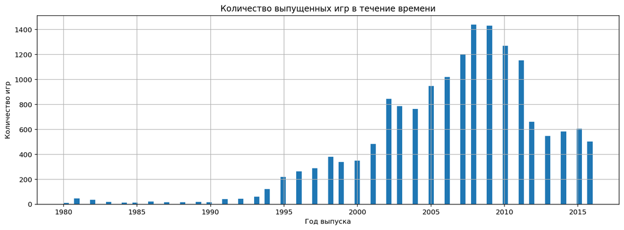

```python
plt.figure(figsize=(15,5));
games['year_of_release'].hist(bins=100);
plt.title('Количество выпущенных игр в течение времени');
plt.xlabel('Год выпуска');
plt.ylabel('Количество игр');
```

Часто игры выпускаются сразу для нескольких платформ и в один год. Если смотреть только по названиям игр, то картина будет немного иная.

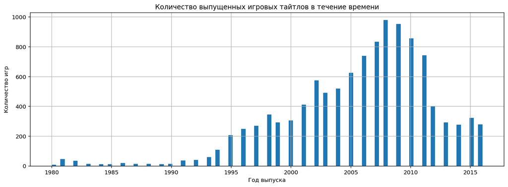

```python
plt.figure(figsize=(15,5));
games.groupby('name')['year_of_release'].min().hist(bins=100);
plt.title('Количество выпущенных игровых тайтлов в течение времени');
plt.xlabel('Год выпуска');
plt.ylabel('Количество игр');
```

Характер распределения не меняется, только сократилось общее число игр.

Проверим распределение выпуска игр по годам.

```python
games.groupby('year_of_release')['name'].count().describe()
```

```
count      37.000000
mean      447.756757
std       455.963900
min         9.000000
25%        36.000000
50%       339.000000
75%       765.000000
max      1440.000000
Name: name, dtype: float64
```

Как видно, для дальнейшего анализа не нужны данные по очень старым играм до 1991 года, так как игр для анализа слишком мало. Отфильтруем датафрейм.

```python
games_filtered_year = games.query('year_of_release > 1990')
```

```python
games_filtered_year.info()
```

```
<class 'pandas.core.frame.DataFrame'>
Int64Index: 16346 entries, 0 to 16714
Data columns (total 12 columns):
 #   Column           Non-Null Count  Dtype
---  ------           --------------  -----
 0   name             16346 non-null  object
 1   platform         16346 non-null  object
 2   year_of_release  16346 non-null  float64
 3   genre            16346 non-null  object
 4   na_sales         16346 non-null  float64
 5   eu_sales         16346 non-null  float64
 6   jp_sales         16346 non-null  float64
 7   other_sales      16346 non-null  float64
 8   critic_score     8073 non-null   float64
 9   user_score       7538 non-null   float64
 10  rating           9866 non-null   object
 11  world_sales      16346 non-null  float64
dtypes: float64(8), object(4)
memory usage: 1.6+ MB
```

```python
games_filtered_year.head()
```

|  | name | platform | year_of_release | genre | na_sales | eu_sales | jp_sales | other_sales | critic_score | user_score | rating | world_sales |
| --- | --- | --- | --- | --- | --- | --- | --- | --- | --- | --- | --- | --- |
| 0 | Wii Sports | Wii | 2006.0 | Sports | 41.36 | 28.96 | 3.77 | 8.45 | 76.0 | 8.0 | E | 82.54 |
| 2 | Mario Kart Wii | Wii | 2008.0 | Racing | 15.68 | 12.76 | 3.79 | 3.29 | 82.0 | 8.3 | E | 35.52 |
| 3 | Wii Sports Resort | Wii | 2009.0 | Sports | 15.61 | 10.93 | 3.28 | 2.95 | 80.0 | 8.0 | E | 32.77 |
| 4 | Pokemon Red/Pokemon Blue | GB | 1996.0 | Role-Playing | 11.27 | 8.89 | 10.22 | 1.00 | NaN | NaN | NaN | 31.38 |
| 6 | New Super Mario Bros. | DS | 2006.0 | Platform | 11.28 | 9.14 | 6.50 | 2.88 | 89.0 | 8.5 | E | 29.80 |

Данных в отфильтрованном по дате выхода датафрейме все еще достаточноо, только порядка 400 игр (около 2%) были удалены.

```python
games = games_filtered_year
```

```python
games.groupby('year_of_release')['name'].count().describe()
```

```
count      26.000000
mean      628.692308
std       429.895408
min        41.000000
25%       301.500000
50%       564.500000
75%       921.500000
max      1440.000000
Name: name, dtype: float64
```

#### Продажи по платформам

Посмотрим, какие платформы самые популярные по общей выручке.

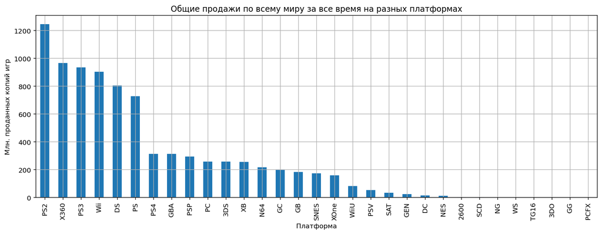

```python
plt.figure(figsize=(15,5));
games.groupby('platform')['world_sales'].sum().sort_values(ascending=False).plot(kind='bar');
plt.title('Общие продажи по всему миру за все время на разных платформах');
plt.xlabel('Платформа');
plt.ylabel('Млн. проданных копий игр');
plt.grid(True, which='both');
```

Сохраним 10 крупнейших по продажам платформ в списке.

```python
biggest_platforms_by_sales = games.groupby('platform')['world_sales'].sum().nlargest(10).index.to_list()
```

```python
biggest_platforms_by_sales
```

```
['PS2', 'X360', 'PS3', 'Wii', 'DS', 'PS', 'PS4', 'GBA', 'PSP', 'PC']
```

Выделим выборку только по крупнейшим платформам.

```python
biggest_platforms_games = games.query('platform.isin(@biggest_platforms_by_sales)')
```

Для этих крупнейших платформ построим распределение по годам выпуска игр.

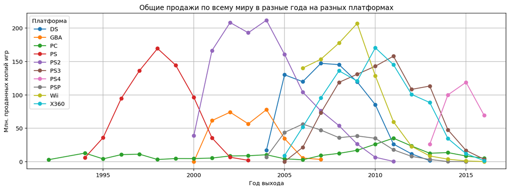

```python
biggest_platforms_games.pivot_table(
    index='year_of_release',
    columns='platform',
    values='world_sales',
    aggfunc='sum').plot(style='o-', figsize=(15,5));
plt.title('Общие продажи по всему миру в разные года на разных платформах');
plt.xlabel('Год выхода');
plt.ylabel('Млн. проданных копий игр');
plt.legend(title='Платформа');
plt.grid(True, which='both');
```

Как видно на графике, платформы появляются (есть продажи игр для них), достигают пика и их популярность затем спадает с выходом новых. Особая ситуация с платформой **PC** так как она существует давно и продажи игр не прекращаются, но уступают другим платформам.

Если посмотреть на платформы Sony (PS, PS2, PS3, PS4), то можно отметить регулярные появления новой версии платформы, что **можно назвать "поколениями" платформ. Промежуток между ними примерно 5-7 лет**. Выход последней платформы задержался на пару лет. Как видно, примерно с выходом PS3 продажи появились и у X360 от Microsoft. Как видно, **период жизни основных платформ - порядка 10 лет**.

Так как по заданию в проекте нам нужны данные для прогнозирования ситуации на рынке после 2016 года, **можно сделать выборку данных для платформ за 10 лет до этого - с 2006 года**, что покажет появление, развитие и закат платформ как минимум в одно "поколение".

```python
games_matters = games.query('year_of_release >= 2006')
```

```python
len(games_matters)
```

```
10416
```

```python
len(games)
```

```
16346
```

```python
len(games_matters) / len(games)
```

```
0.6372201150128471
```

```python
games = games_matters
```

Итого в выборке осталось 63% от изначальной (10 тыс. игр), что должно быть достаточно для анализа.

Посмотрим по уточненной выборке какие платформы лидируют по продажам, растут или падают.

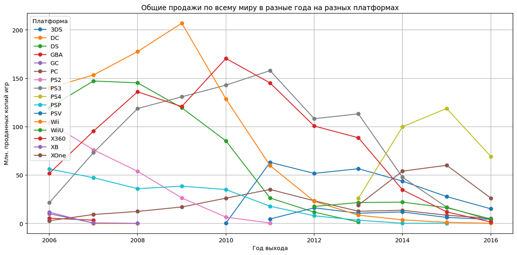

```python
games.pivot_table(
    index='year_of_release',
    columns='platform',
    values='world_sales',
    aggfunc='sum').plot(style='o-', figsize=(15,7));
plt.title('Общие продажи по всему миру в разные года на разных платформах');
plt.xlabel('Год выхода');
plt.ylabel('Млн. проданных копий игр');
plt.legend(loc='upper left', title='Платформа');
plt.grid(True, which='both');
```

Если учесть, что по условиям данные за 2016 год могут быть неполными, посмотрим подробнее на годы с 2013 по 2015 включительно.

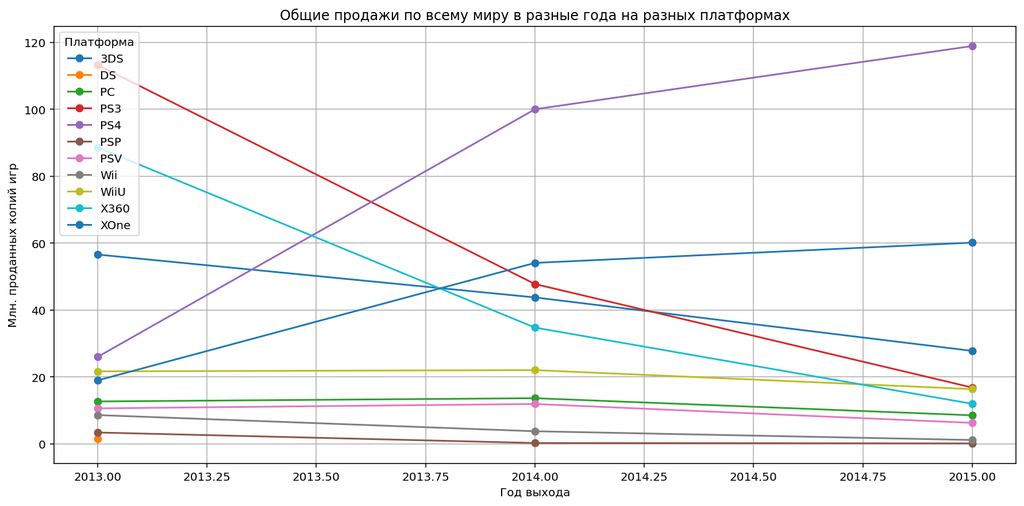

```python
games.query('2013 <= year_of_release <= 2015').pivot_table(
    index='year_of_release',
    columns='platform',
    values='world_sales',
    aggfunc='sum').plot(style='o-', figsize=(15,7));
plt.title('Общие продажи по всему миру в разные года на разных платформах');
plt.xlabel('Год выхода');
plt.ylabel('Млн. проданных копий игр');
plt.legend(loc='upper left', title='Платформа');
plt.grid(True);
```

Как видно по предыдущим годам:

- для платформ PS4 и XOne наблюдается рост продаж
- для платформ PSV, PS3 и X360 наблюдается падение продаж
- платформа PS4 является лидером продаж за 2015 год, в 2 раза меньшие успехи у XOne, остальные по продажам уступают еще в 2 раза.

По видимому, происходит смена "поколений" платформ.

Таким образом, можно выделить платформы **PS4 и XOne** как потенциально прибыльные в ближайшие годы. Если предположить, что платформы достигнут своего пика продаж примерно через то же время, что и прошлое поколение, то эти плафтформы достигнут пика в 2017-2018 годах, что как раз необходимо заказчикам исследования.

#### Изучение распределений продаж

Посмотрим на **диаграмму размаха** по глобальным продажам игр в разбивке по платформам.

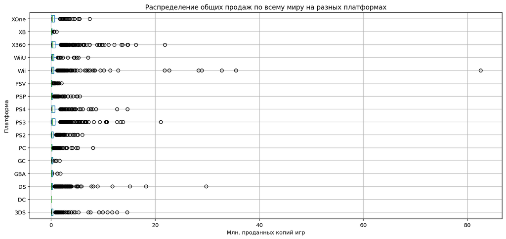

```python
games[['platform', 'world_sales']].boxplot(by='platform', figsize=(15,7), vert=False);
plt.title('Распределение общих продаж по всему миру на разных платформах');
plt.suptitle('');
plt.ylabel('Платформа');
plt.xlabel('Млн. проданных копий игр');
plt.grid(True);
```

Как видно по графику, на нескольких платформах есть выдающиеся игры, которые продаются сильно лучше, чем в среднем на платформе. Среди таких платформ DS, PS3, PS4, Wii, X360.

Посмотрим подробнее на продажи до 5 млн. копий.

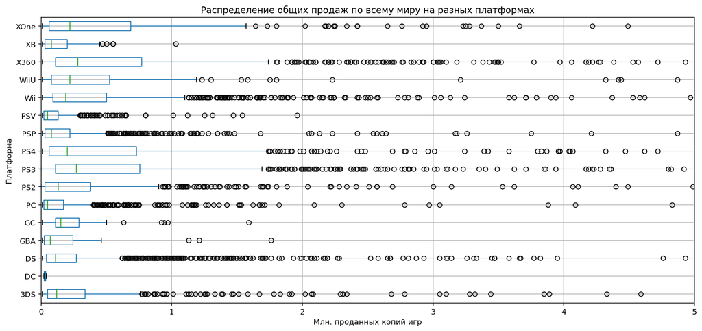

```python
games[['platform', 'world_sales']].boxplot(by='platform', figsize=(15,7), vert=False);
plt.title('Распределение общих продаж по всему миру на разных платформах');
plt.suptitle('');
plt.ylabel('Платформа');
plt.xlabel('Млн. проданных копий игр');
plt.xlim(0, 5);
plt.grid(True);
```

На всех популярных платформах распределение не симметрично и смещено вправо (медиана (вертикальная зеленая линия) смещена в левую часть межквартильного интервала). Для наиболее популярных платформ наблюдаются длинные "усы" вплоть до **1,7 млн. проданных копий** (платформы XOne, X360, PS3, PS4). Это значит, что на этих платформах много "нормальных" игр по продажам, превышающим 1 млн. копий, чего нельзя сказать о других платформах. По всем платформам наблюдаются "выбросы" продаж игр, сильно превышающих характерное распределение, но их количество невелико.

По медианам продаж лидирует платформа X360, за ней PS3 и XOne.

Выделенные по графику **платформы XOne, X360, PS3 и PS4 можно назвать самыми популярными**.

#### Влияние отзывов на продажи

Посмотрим, как влияют на продажи внутри одной популярной платформы отзывы пользователей и критиков.

```python
popular_platforms = ['XOne', 'X360', 'PS3', 'PS4']
```

Посмотрим на выборку по популярным платформам.

```python
games.query('platform.isin(@popular_platforms)').groupby('platform')[['name', 'user_score', 'critic_score']].count()
```

| platform | name | user_score | critic_score |
| --- | --- | --- | --- |
| PS3 | 1319 | 869 | 813 |
| PS4 | 392 | 257 | 252 |
| X360 | 1229 | 938 | 887 |
| XOne | 247 | 182 | 169 |

Посмотрим отзывы и продажи для **PS3**, так как у нее достаточно много отзывов и игр в выборке. Также удалим из выборки выбросы по продажам свыше 1,7 млн. копий (по итогам уже проведенного анализа).

```python
ps3_games = games.query('platform == "PS3" and world_sales <= 1.7')
```

```python
ps3_games.head()
```

|  | name | platform | year_of_release | genre | na_sales | eu_sales | jp_sales | other_sales | critic_score | user_score | rating | world_sales |
| --- | --- | --- | --- | --- | --- | --- | --- | --- | --- | --- | --- | --- |
| 1052 | Portal 2 | PS3 | 2011.0 | Shooter | 0.83 | 0.60 | 0.02 | 0.24 | 95.0 | 8.4 | E10+ | 1.69 |
| 1060 | BioShock Infinite | PS3 | 2013.0 | Shooter | 0.72 | 0.65 | 0.04 | 0.28 | 94.0 | 8.5 | M | 1.69 |
| 1062 | Call of Duty: Black Ops 3 | PS3 | 2015.0 | Shooter | 0.49 | 0.87 | 0.07 | 0.26 | NaN | NaN | NaN | 1.69 |
| 1075 | Saints Row 2 | PS3 | 2008.0 | Action | 0.88 | 0.54 | 0.02 | 0.25 | 82.0 | 7.9 | M | 1.69 |
| 1091 | Dragon Age: Origins | PS3 | 2009.0 | Role-Playing | 0.96 | 0.42 | 0.08 | 0.21 | 87.0 | 7.9 | M | 1.67 |

Построим диаграммы рассеяния по интересующим нас параметрам.

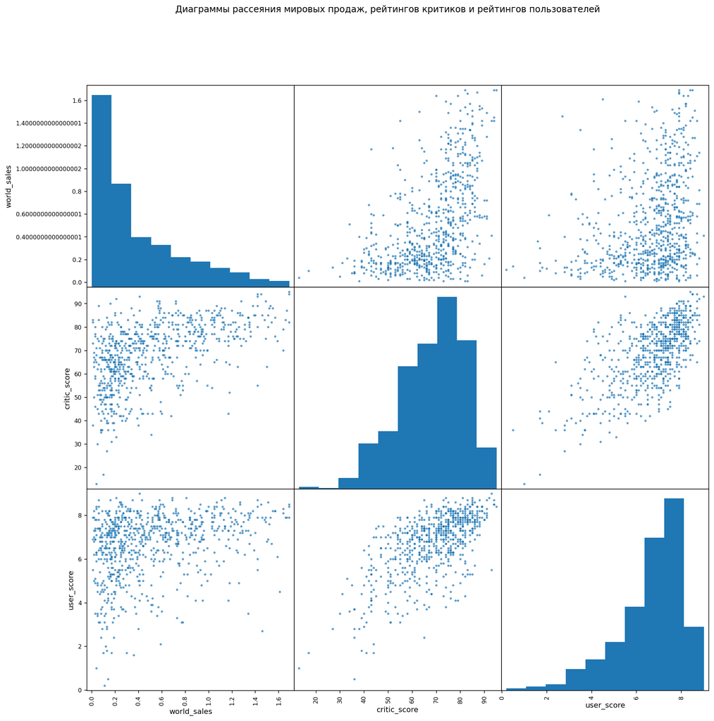

```python
pd.plotting.scatter_matrix(ps3_games[['world_sales', 'critic_score', 'user_score']], alpha=0.7, figsize=(15,15));
plt.suptitle('Диаграммы рассеяния мировых продаж, рейтингов критиков и рейтингов пользователей');
```

Как видно по диаграммам рассеяния, продажи показывают некоторую зависимость от рейтинга критиков, но зависимость от рейтинга пользователей более хаотична. В то же время, рейтинг пользователей показывает линейную зависимость от рейтинга критиков.

Проверим корреляцию.

```python
ps3_games['world_sales'].corr(ps3_games['critic_score'])
```

```
0.5230682796180766
```

```python
ps3_games['world_sales'].corr(ps3_games['user_score'])
```

```
0.28342359186415794
```

```python
ps3_games['critic_score'].corr(ps3_games['user_score'])
```

```
0.6469528719032711
```

Итого можно заключить, что **мировые продажи в целом показывают среднюю корреляцию 0.52 от рейтинга критиков и слабую (0.28) от рейтинга пользователей**. Между собой **рейтинги пользователей и критиков связаны также со средним коэффициентом корреляции Пирсона 0.64**.

Проверим этот вывод на второй популярной платформе **X360**.

```python
x360_games = games.query('platform == "X360" and world_sales <= 1.7')
```

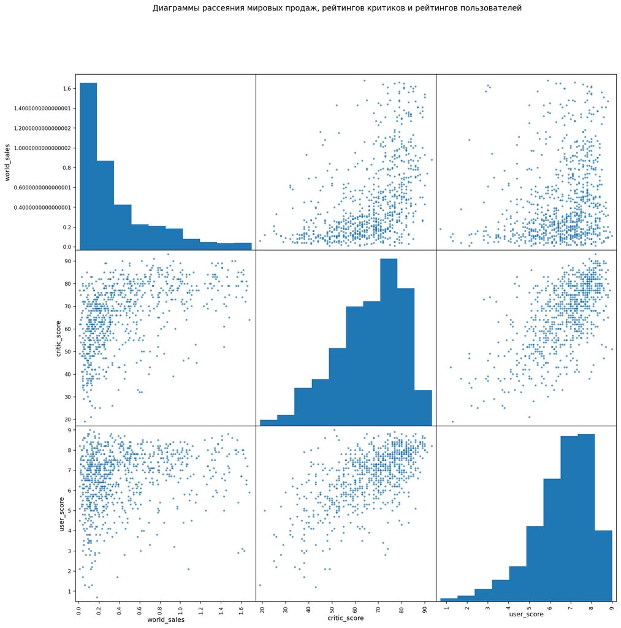

```python
pd.plotting.scatter_matrix(x360_games[['world_sales', 'critic_score', 'user_score']], alpha=0.7, figsize=(15,15));
plt.suptitle('Диаграммы рассеяния мировых продаж, рейтингов критиков и рейтингов пользователей');
```

```python
x360_games['world_sales'].corr(x360_games['critic_score'])
```

```
0.48876969046857766
```

```python
x360_games['world_sales'].corr(x360_games['user_score'])
```

```
0.214662473169124
```

```python
x360_games['critic_score'].corr(x360_games['user_score'])
```

```
0.6342692337801112
```

Как видно, эти же выводы верны для платформы X360 примерно с такими же показателя корреляции.

```python
xone_games = games.query('platform == "XOne" and world_sales <= 1.7')
```

#### Зависимость продаж от жанра игры

Посмотрим на общее распределение игр по жанрам.

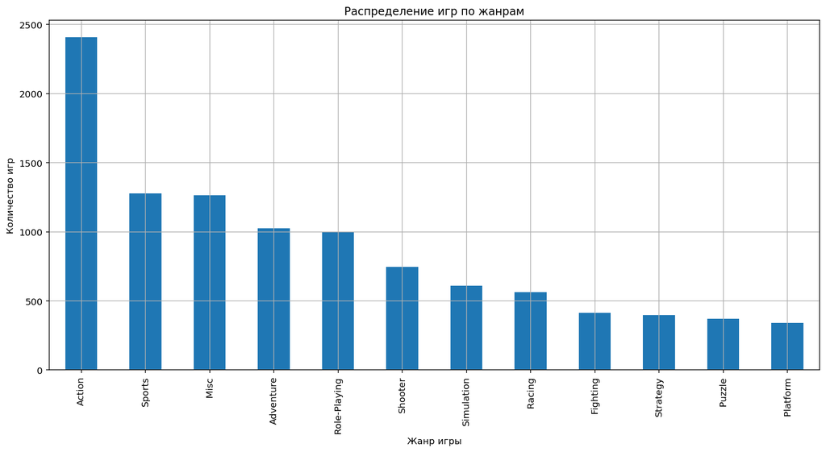

```python
plt.figure(figsize=(15,7));
games.groupby('genre')['name'].count().sort_values(ascending=False).plot(kind='bar');
plt.grid(True);
plt.title('Распределение игр по жанрам');
plt.xlabel('Жанр игры');
plt.ylabel('Количество игр');
```

```python
games.groupby('genre')['name'].count().sort_values(ascending=False)
```

```
genre
Action          2409
Sports          1277
Misc            1265
Adventure       1024
Role-Playing     998
Shooter          747
Simulation       609
Racing           564
Fighting         415
Strategy         397
Puzzle           370
Platform         341
Name: name, dtype: int64
```

По распределению видно, что **наиболее частым жанром является Action**, которого в выборке представлено практически в 2 раза больше, чем другие жанры. Также большое количество игр в данных входят в категории Sports, Misc, Adventure, Role-Playing и Shooter.

Посмотрим зависимость общих продаж от жанра.

```python
games.groupby('genre')['world_sales'].sum().sort_values(ascending=False)
```

```
genre
Action          1132.65
Sports           798.50
Shooter          722.36
Misc             557.78
Role-Playing     522.76
Racing           299.08
Platform         280.22
Simulation       221.15
Fighting         188.65
Adventure        141.37
Puzzle            90.57
Strategy          73.77
Name: world_sales, dtype: float64
```

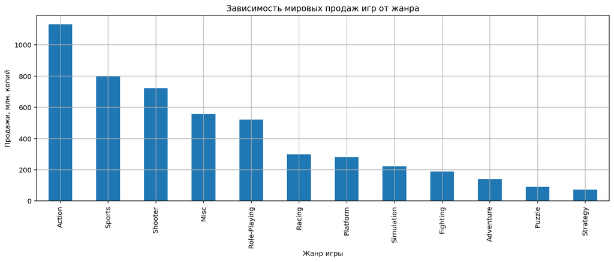

```python
plt.figure(figsize=(15,5));
games.groupby('genre')['world_sales'].sum().sort_values(ascending=False).plot(kind='bar', grid=True);
plt.title('Зависимость мировых продаж игр от жанра');
plt.xlabel('Жанр игры');
plt.ylabel('Продажи, млн. копий');
```

Как видно по графику, **наиболее прибыльным жанром является Action, за ним следуют Sports, Shooter, Misc, Role-Playing. Наименее прибыльным жанром являются стратегии.** Разница в продажах между Action и Strategy достигает десятков раз.

### Вывод раздела 3

В этом разделе мы:

- изучили сколько игр выпускалось в разные годы и обнаружили, что количество данных в выборке старше 1990 года слишком мало, ими можно пренебречь без потери данных для анализа.
- изучили изменение продаж по платформам, **на характерном промежутке времени 10 лет возникает новое поколение платформ**, которое сменяет предыдущее.
- на основе полученных выводов данные в выборке **ограничили 2006 годом** за 10 лет до исследуемого.
- исследовали рост и падение разных платформ и выделили наиболее перспективные - **XOne и PS4**
- проанализировали глобальные продажи игр в разбивке по платформам и выделили основные PS3, PS4, X360, XOne, а также характерные разбросы продаж для них на уровне **1,7 млн. копий**.
- обнаружили среднюю положительную корреляцию между отзывами критиков и мировыми продажами игр для платформы PS3 и не обнаружили ее для рейтинга пользователей, полученные выводы подтвердились для платформы X360
- изучили зависимость продаж от жанра игры и выделили наиболее популярный (**Action**) и наименее (**Strategy**).

## 4. Изученение пользователей из разных регионов

Определим для пользователя каждого региона (NA, EU, JP) самые популярные платформы (ТОП-5).

```python
games.groupby('platform')['na_sales'].sum().nlargest(5).reset_index()
```

|  | platform | na_sales |
| --- | --- | --- |
| 0 | X360 | 591.47 |
| 1 | Wii | 494.01 |
| 2 | PS3 | 391.60 |
| 3 | DS | 325.06 |
| 4 | PS2 | 115.75 |

```python
games.groupby('platform')['eu_sales'].sum().nlargest(5).reset_index()
```

|  | platform | eu_sales |
| --- | --- | --- |
| 0 | PS3 | 328.83 |
| 1 | X360 | 269.25 |
| 2 | Wii | 261.48 |
| 3 | DS | 143.30 |
| 4 | PS4 | 141.09 |

```python
games.groupby('platform')['jp_sales'].sum().nlargest(5).reset_index()
```

|  | platform | jp_sales |
| --- | --- | --- |
| 0 | DS | 141.49 |
| 1 | 3DS | 100.64 |
| 2 | PS3 | 79.51 |
| 3 | PSP | 71.13 |
| 4 | Wii | 69.05 |

Тройка лидеров по продажам не отличается для NA и EU, но порядок их различен. **На рынке NA лидирует X360, на рынке EU - PS3**. Для **региона JP ситуация в корне иная и лидирует платформа DS, а X360 отсутствует в пятерке лидеров**. В то же время, на других рынках платформа DS находится на 4-ом месте по продажам.

Проверим распределение продаж по всему миру.

```python
games.groupby('platform')['world_sales'].sum().nlargest(5).reset_index()
```

|  | platform | world_sales |
| --- | --- | --- |
| 0 | X360 | 957.39 |
| 1 | PS3 | 935.00 |
| 2 | Wii | 903.31 |
| 3 | DS | 656.85 |
| 4 | PS4 | 314.14 |

**Платформа PS3 входит в тройку лидеров для всех регионов и является из-за этого одной из самых прибыльных**. В то же время, **лидером по абсолютным продажам является X360 за счет рынка NA, несмотря на очень скромные продажи в регионе JP**.

Скорее всего, на долю продаж влияют как культурные различия (платформа из NA плохо продается в JP), так и качественная разница платформ по их мощности (в лидерах продаж мощные платформы X360 и PS3, а также относительно слабая Wii).

Посмотрим на самые популярные жарны и выделим топ-5 в каждом регионе.

```python
games.groupby('genre')['na_sales'].sum().nlargest(5).reset_index()
```

|  | genre | na_sales |
| --- | --- | --- |
| 0 | Action | 538.92 |
| 1 | Sports | 399.54 |
| 2 | Shooter | 375.65 |
| 3 | Misc | 286.20 |
| 4 | Role-Playing | 199.71 |

```python
games.groupby('genre')['eu_sales'].sum().nlargest(5).reset_index()
```

|  | genre | eu_sales |
| --- | --- | --- |
| 0 | Action | 356.35 |
| 1 | Sports | 252.52 |
| 2 | Shooter | 241.06 |
| 3 | Misc | 147.43 |
| 4 | Racing | 113.42 |

```python
games.groupby('genre')['jp_sales'].sum().nlargest(5).reset_index()
```

|  | genre | jp_sales |
| --- | --- | --- |
| 0 | Role-Playing | 170.58 |
| 1 | Action | 102.08 |
| 2 | Misc | 65.55 |
| 3 | Sports | 49.25 |
| 4 | Platform | 35.20 |

Проверим зависимость продаж от рейтинга ESRB.

```python
games.groupby('rating')['na_sales'].sum().nlargest(5).reset_index()
```

|  | rating | na_sales |
| --- | --- | --- |
| 0 | E | 800.93 |
| 1 | M | 576.57 |
| 2 | T | 426.74 |
| 3 | E10+ | 322.46 |
| 4 | EC | 1.32 |

```python
games.groupby('rating')['eu_sales'].sum().nlargest(5).reset_index()
```

|  | rating | eu_sales |
| --- | --- | --- |
| 0 | E | 462.11 |
| 1 | M | 401.36 |
| 2 | T | 236.87 |
| 3 | E10+ | 178.24 |
| 4 | RP | 0.03 |

```python
games.groupby('rating')['jp_sales'].sum().nlargest(5).reset_index()
```

|  | rating | jp_sales |
| --- | --- | --- |
| 0 | E | 120.36 |
| 1 | T | 84.08 |
| 2 | M | 43.82 |
| 3 | E10+ | 36.57 |
| 4 | EC | 0.00 |

На этих сводных данных можно сделать вывод, что для рынков EU и NA рейтинги одинаково влияют на продажи игр и первые 3 места занимают игры для возрастных групп E, M, T. В то же время для рынка JP наиболее популярным рейтингом являются игры с E, а далее T и M. Для рынка EU разница в продажах между рейтингами E и M практическ отсутствует, в то время как для NA игры с E опережают M в 1,5 раза. Таким образом, **для всех регионов наиболее популярными являются игры с рейтингом E**, а тройка лидеров по продажам не отличается.

### Вывод раздела 4

В этом разделе мы определили для пользователей каждого региона (NA, EU, JP):

- самые популярные платформы (топ-5)
- самые популярные жанры (топ-5)
- зависимость продаж от рейтинга ESRB на разных рынках.

В результате можно составить 3 разных "портрета" пользователя для разных регионов с наибольшими продажами (наиболее популярны):

- для региона **NA** пользователи:
  - используют платформу **X360**
  - играют в жанр **Action**
  - с рейтингом ESRB E
- для региона **EU** пользователи:
  - используют платформу **PS3**
  - играют в жанр **Action**
  - с рейтингом ESRB E
- для региона **JP** пользователи:
  - используют платформу **DS**
  - играют в жанр **Role-Playing**
  - с рейтингом ESRB E

## 5. Проверка гипотез

Проверим следующие гипотезы:

- Средние пользовательские рейтинги платформ Xbox One и PC одинаковые;
- Средние пользовательские рейтинги жанров Action (англ. «действие», экшен-игры) и Sports (англ. «спортивные соревнования») разные.

Подготовим пользовательские рейтинги платформ Xbox One и PC.

```python
xbox_ratings = games.query('platform == "XOne"')['user_score'].reset_index(drop=True)
```

```python
pc_ratings = games.query('platform == "PC"')['user_score'].reset_index(drop=True)
```

```python
ratings = pd.DataFrame({'xbox': xbox_ratings, 'pc': pc_ratings})
```

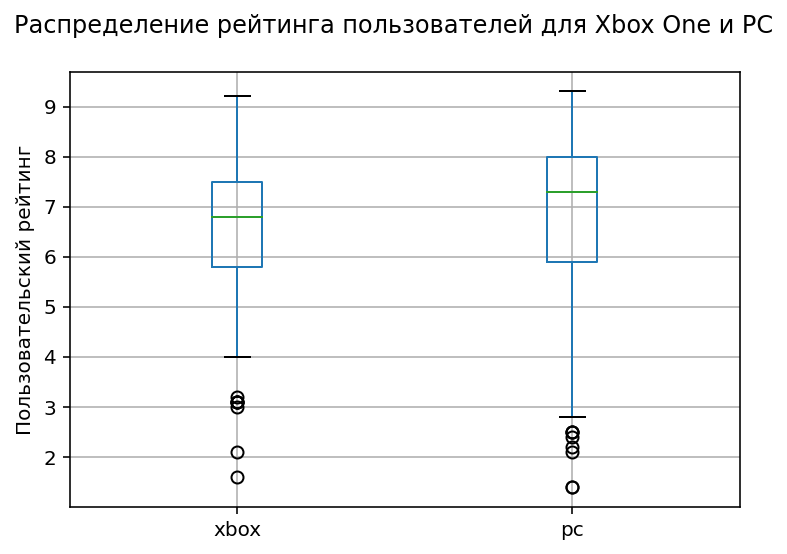

```python
ratings.boxplot();
plt.ylabel('Пользовательский рейтинг');
plt.suptitle('Распределение рейтинга пользователей для Xbox One и PC');
```

```python
ratings.describe()
```

|  | xbox | pc |
| --- | --- | --- |
| count | 182.000000 | 626.000000 |
| mean | 6.521429 | 6.835942 |
| std | 1.380941 | 1.516586 |
| min | 1.600000 | 1.400000 |
| 25% | 5.800000 | 5.900000 |
| 50% | 6.800000 | 7.300000 |
| 75% | 7.500000 | 8.000000 |
| max | 9.200000 | 9.300000 |

Как видно по распределениям оценок, для PC очень широк диапазон характерных значений пользовательских оценок от 3.0 до 9.3, тогда как для Xbox One характерные оценки начинаются с 4.0 и до 9.2. Медианные значения чуть выше для PC и составляет 7.3. Средние значения чуть ниже.

Избавимся от выбросов в оценках для подготовки к работе с гипотезами, чтобы результаты были надежнее.

```python
xbox_ratings = xbox_ratings[xbox_ratings >= 4.0]
pc_ratings = pc_ratings[pc_ratings >= 3.0]
ratings = pd.DataFrame({'xbox': xbox_ratings, 'pc': pc_ratings})
```

```python
ratings.describe()
```

|  | xbox | pc |
| --- | --- | --- |
| count | 174.000000 | 616.000000 |
| mean | 6.693103 | 6.910065 |
| std | 1.142990 | 1.410332 |
| min | 4.000000 | 3.000000 |
| 25% | 5.900000 | 6.000000 |
| 50% | 6.800000 | 7.300000 |
| 75% | 7.500000 | 8.000000 |
| max | 9.200000 | 9.300000 |

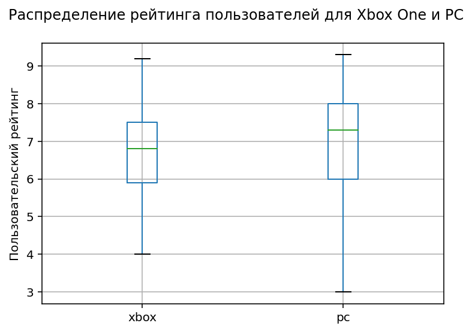

```python
ratings.boxplot();
plt.ylabel('Пользовательский рейтинг');
plt.suptitle('Распределение рейтинга пользователей для Xbox One и PC');
```

Теперь данные подготвлены, можно использовать для работы с гипотезами.

Так как мы хотим изучить среднее двух выборок, для этого подойдет использование гипотезы о равенстве средних двух генеральных совокупностей.

Для первой гипотезы сформулируем нулевую гипотезу таким образом: средние пользовательские рейтинги платформ Xbox One и PC одинаковые (не отличаются). Альтернативной гипотезой будет ситуация, обратная этой.

Примем пороговое значение вероятности за 5%.

```python
alpha = 0.05
sample1 = xbox_ratings.to_list()
sample2 = pc_ratings.to_list()
```

```python
result = st.ttest_ind(sample1, sample2, equal_var=True)
result.pvalue
```

```
0.06276780710517475
```

```python
result.pvalue < alpha
```

```
False
```

Нулевую гипотезу нельзя отвергнуть. Получается, что есть вероятность выше 5% совпадения выборок и их средних по платформам Xbox One и PC. В то же время, разница очень не велика и при выборе критического значения p-value другим распределения уже будут отличаться и нулевую гипотезу нужно будет отвергнуть.

Проверим гипотезу о том, что средние пользовательские рейтинги жанров Action и Sports разные.

```python
action_ratings = games.query('genre == "Action"')['user_score'].reset_index(drop=True)
```

```python
sports_ratings = games.query('genre == "Sports"')['user_score'].reset_index(drop=True)
```

```python
genre_ratings = pd.DataFrame({'action': action_ratings, 'sports': sports_ratings})
```

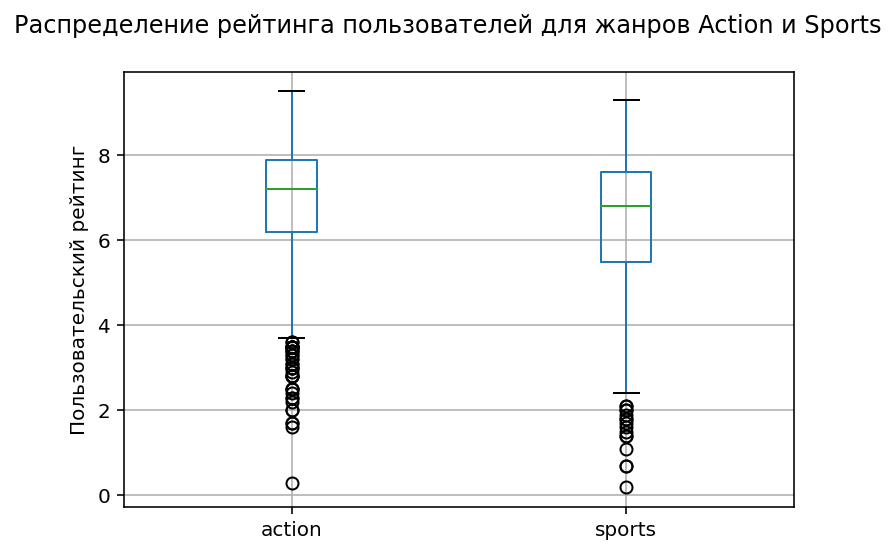

```python
genre_ratings.boxplot();
plt.ylabel('Пользовательский рейтинг');
plt.suptitle('Распределение рейтинга пользователей для жанров Action и Sports');
```

```python
genre_ratings.describe()
```

|  | action | sports |
| --- | --- | --- |
| count | 1343.000000 | 682.000000 |
| mean | 6.881013 | 6.418622 |
| std | 1.359979 | 1.647244 |
| min | 0.300000 | 0.200000 |
| 25% | 6.200000 | 5.500000 |
| 50% | 7.200000 | 6.800000 |
| 75% | 7.900000 | 7.600000 |
| max | 9.500000 | 9.300000 |

Аналогично предыдущей гипотезе избавимся от выбросов.

```python
action_ratings = action_ratings[action_ratings >= 3.8]
sports_ratings = sports_ratings[sports_ratings >= 2.2]
genre_ratings = pd.DataFrame({'action': action_ratings, 'sports': sports_ratings})
```

```python
genre_ratings.describe()
```

|  | action | sports |
| --- | --- | --- |
| count | 1298.000000 | 666.000000 |
| mean | 7.017720 | 6.536787 |
| std | 1.156535 | 1.474948 |
| min | 3.800000 | 2.400000 |
| 25% | 6.300000 | 5.625000 |
| 50% | 7.200000 | 6.800000 |
| 75% | 7.900000 | 7.700000 |
| max | 9.500000 | 9.300000 |

Для второй гипотезы сформулируем нулевую гипотезу таким образом: средние пользовательские рейтинги жанров Action и Sports одинаковые (не отличаются). Альтернативной гипотезой будет ситуация, обратная этой.

Примем пороговое значение вероятности за 5%.

```python
alpha = 0.05
sample1 = action_ratings.to_list()
sample2 = sports_ratings.to_list()
```

```python
result = st.ttest_ind(sample1, sample2, equal_var=True)
result.pvalue
```

```
3.833782784088702e-15
```

```python
result.pvalue < alpha
```

```
True
```

Нулевую гипотезу нужно отвергнуть. Получается, что вероятность совпадения выборок и их средних по жанрам Action и Sports очень мала. Соответственно, альтернативная гипотеза о различии пользовательских оценок может быть подтверждена.

### Вывод раздела 5

В этом разделе мы проверили 2 гипотезы:

- средние пользовательские рейтинги платформ Xbox One и PC одинаковые - **гипотеза подтверждена**, но p-value схож с выбранным пороговым значением и отличается только на 1 процентный пункт, поэтому требуется отдельно подробное изучение в зависимости от задачи.
- средние пользовательские рейтинги жанров Action и Sports разные - **гипотеза подтверждена**, обнаружена значительная статистическая разница

## 6. Общий вывод и рекомендации

В ходе проекта были проведены следующие работы:

- загружены и описаны исходные данные
- сделаны преобразования типов и обработаны пропуски
- добавлен параметр продаж по всему миру
- проанализирован выпуск игр в разные годы и продажи по платформам, выделен характерный период игровых платформ (10 лет)
- выделены набирающие популярность платформы XOne и PS4, которые интересны для планирования продаж на 2017 год
- выделены в целом популярные платформы с продажами свыше 1 млн. копий - X360, XOne, PS3, PS4
- изучено влияние на продажи отзывов критиков и пользователей, обнаружена средняя корреляция между отзывами критиков и продажами, но не обнаружена с отзывами пользователей
- выделен самый прибыльный жанр - Action и наименее прибыльный - Strategy
- cоставили портрет пользователя каждого региона (NA, EU, JP), разница в продажах от рейтинга ESRB не зависит от региона и основные жанры и платформы оцень схожи в регионах NA и EU и отличаются в JP
- проверили гипотезы:
  - средние пользовательские рейтинги платформ Xbox One и PC одинаковые - подтверждена
  - средние пользовательские рейтинги жанров Action и Sports разные - подтверждена

По результатам работы можно сделать следующие наблюдения и выводы:

- на периоде 10 лет возникают и сменяются другими основные игровые платформы, кроме PC, для подготовки к 2017 году стоит обратить внимание на игры для новых платформ XOne и PS4 как набирающие популярность к 2015-2016 годам.
- в промежутке с 2006 по 2016 года сохраняют популярность основные платформы, на которых возможны высокие продажи игр (свыше 1 млн. копий) - X360, PS3, игры для этих платформ также еще будут пользоваться некоторой популярностью
- с точки зрения наполнения разными играми интернет-магазина некоторую среднюю корреляцию с продажами показывают оценки критиков, а оценки пользователей имеют слишком большой разброс и могут не отражать реальность
- по жанрам игр лидирует Action как самый прибыльный и самый популярный в регионах NA и EU, за ним следуют Sports и Shooter, в JP продажи в целом игр ниже и лидирует жанр Role-Playing, это стоит учесть при закупке игр на продажу в интернет-магазин
- по пользовательским оценкам в среднем платформы XOne и PC не отличаются, но значительно отличаются оценки для Action и Sports (лидирует в среднем Action).